# Effect of Financial Ratios on Earnings per Share

Kai Xing ID: 389862; Adrian Hirt ID:K-14561

20/05/2022

```r
Sys.setenv(LANG = "en")

options(scipen=999)
library("MASS")
library("sandwich")
library("zoo")
library("car")
library("lmtest")
library("Formula")
library("plm")
library("stargazer")
library("pcse")
library("pacman")
library("ggplot2")
library("skimr")
library("psych")
library("groundhog")
```

```r
pkgs <- c("MASS",
          "sandwich",
          "zoo",
          "car",
          "lmtest",
          "Formula",
          "plm",
          "stargazer",
          "pcse",
          "pacman",
          "ggplot2",
          "skimr",
          "psych")
groundhog.library(pkgs, "2022-06-05")
```

## 1. Introduction

### 1.1 Background and Aim

Many firms include selected key **financial ratios** as part of their corporate objectives. These ratios can be easily obtained from a company’s financial report, giving shareholders and potential investors the ability to make informed decisions about their investment in a given company.

In general, investors focus on the earnings they can gain in the potential investment through target’s profitability ratios like earning per share, dividend yield and price/earnings ratio. Among these ratios, **Earnings Per Share (EPS)** receives the most attention from the financial community and investors. It is used by investors as an indicator of the profitability of listed companies, making it an important tool in the decision making process for investments.

The **primary aim** of this Reproducible research is to **investigate the influence of various financial ratios on EPS and identify the most important determinants of EPS** through an econometric analysis.

Particularly, **EPS** describes a company’s profit or loss during a reporting period, divided by the weighted average number of outstanding ordinary shares during the same reporting period. By analyzing a company’s EPS over the years, it becomes apparent if the performance of the company has improved from an investor’s point of view. By comparing similar companies based on their EPS, conclusions about the best possible investment may be drawn.

#### Data

The analysis is based on the [financial data](https://1drv.ms/u/s!AnpDgcQUjRx0jYxr6QH653-FsPViCA?e=MQB0bU) (Access requires author’s permit) from the [RESSET](https://www.resset.cn/endatabases) database. The dataset includes data from financial reports of non-financial companies listed at Shanghai Stock Exchange, ranging from 2009 to 2018. Previously, the analysis was conducted in Stata. To increase the reproducibility and test the model robustness, this project will be performed in R.The econometric model is a panel data model which requires hypothesis testing and best model selection.

#### Hypotheses

Based on the results, this research is designed to test the following hypotheses using the given dataset:

**Hypothesis 0**: The variables under investigation do not significantly influence EPS

**Hypothesis 1**: Return on asset has positive influence on EPS.

**Hypothesis 2**: Debt to equity has negative influence on EPS.

**Hypothesis 3**: Logarithm of total assets has positive influence on EPS.

#### Definitions

The term **Return on Assets (ROA)** refers to a financial ratio that indicates how profitable a company is in relation to its total assets. Corporate management, analysts, and investors can use ROA to determine how efficiently a company uses its assets to generate a profit.

The term **Debt to Equity** ratio compares a company’s total liabilities to its shareholder equity and can be used to evaluate how much leverage a company is using.

The term **Total Assets** is all the assets that one company owns. Included in total assets is cash, accounts receivable, inventory, equipment etc.

### 1.2 Data processing

First, load the data and check its structure. There are no missing values in the dataset. All 6 variables are numeric.

```r
dataset = read.csv(file = "dataset.csv",
                   sep = ",",
                   header = TRUE)

skim(dataset)
```

Data summary

| Name | dataset |
| --- | --- |
| Number of rows | 5940 |
| Number of columns | 6 |
| _______________________ |  |
| Column type frequency: |  |
| numeric | 6 |
| ________________________ |  |
| Group variables | None |

**Variable type: numeric**

| skim_variable | n_missing | complete_rate | mean | sd | p0 | p25 | p50 | p75 | p100 | hist |
| --- | --- | --- | --- | --- | --- | --- | --- | --- | --- | --- |
| CompanyCode | 0 | 1 | 1878.93 | 5135.09 | 1054.00 | 1245.00 | 1435.50 | 1668.00 | 74422.00 | ▇▁▁▁▁ |
| EPS | 0 | 1 | 0.31 | 0.52 | -3.89 | 0.06 | 0.22 | 0.48 | 4.36 | ▁▁▇▁▁ |
| ROA | 0 | 1 | 3.53 | 5.85 | -64.48 | 1.07 | 2.98 | 5.81 | 47.70 | ▁▁▇▇▁ |
| Dbequrt | 0 | 1 | 200.14 | 551.78 | 1.72 | 63.24 | 117.11 | 214.94 | 24961.15 | ▇▁▁▁▁ |
| LOGTA | 0 | 1 | 22.44 | 1.26 | 18.83 | 21.59 | 22.35 | 23.28 | 27.67 | ▁▇▇▂▁ |
| year | 0 | 1 | 2013.50 | 2.87 | 2009.00 | 2011.00 | 2013.50 | 2016.00 | 2018.00 | ▇▇▇▇▇ |

For the dependent variable EPS, let’s check its distribution. For the histogram, one can find that it is quasi-normal distributed and right-skewed which means that more companies are generating a profit rather than a loss.

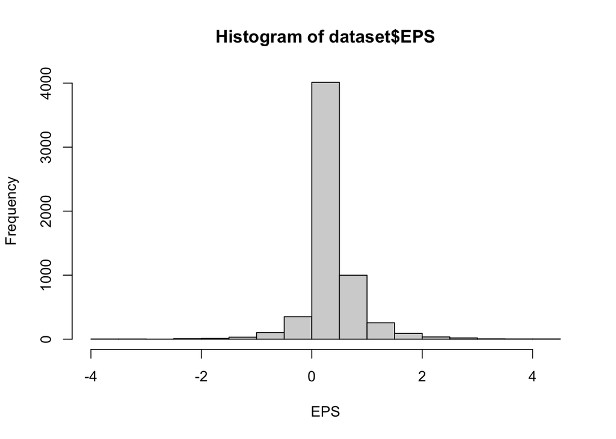

```r
hist(dataset$EPS, xlab = "EPS")
```

Next, check for a correlation between EPS and time. From boxplot, it is also clear to see that EPS is rather steady in different years.

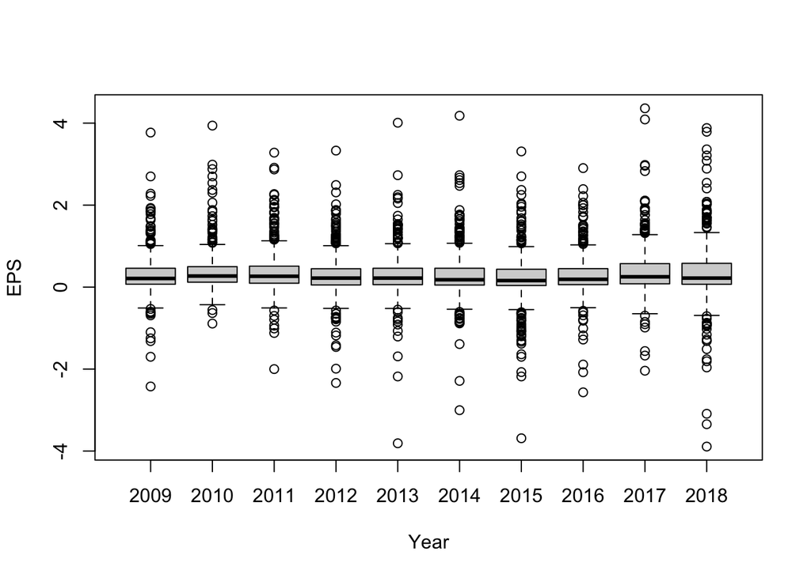

```r
boxplot(dataset$EPS~dataset$year,
        dataset,
        xlab="Year",
        ylab="EPS")
```

It would also be useful to check the correlation for all the variables since all the independent variables should not be correlated with each other.

R psych package has great advantage in the data visualization. The graphs below show the correlation and distribution for the dataset.

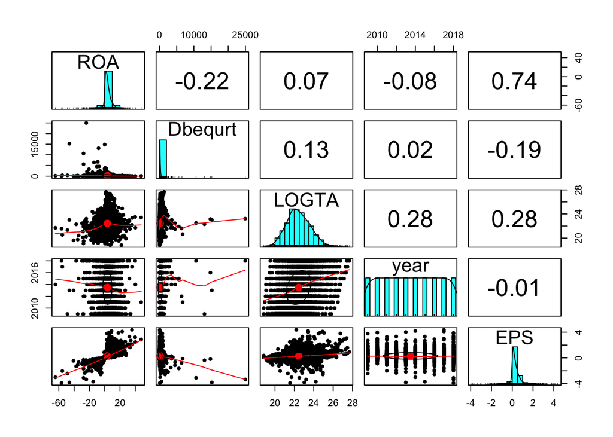

```r
pairs.panels(dataset[c("ROA", "Dbequrt", "LOGTA", "year", "EPS")])
```

Next step will be select the most appropriate model.

### 1.3 Model selection

First, one should choose between random and fixed effect model.

**Hausmann test** therefore should be used. It evaluates the consistency of an estimator when compared to an alternative, less efficient estimator which is already consistent. The alternative hypothesis assumes the mismatch of the random effects model estimator with the simultaneous consistency of the fixed effects estimator.

**The null hypothesis** assume that this statistic has asymptotically the chi-squared distribution with the number of degrees of freedom equal to the rank of matrix.

If the study rejects the null hypothesis, it means that $β_R$, our random effect estimator, is inconsistent. Then methods are used that do not assume that there is a correlation between individual effects and explanatory variables. So, fixed effect model is preferred and vice versa.

```r
random <-plm(EPS~ROA+Dbequrt+LOGTA,
             data = dataset,
             index = c("CompanyCode", "year"),
             model = "random")

summary(random)
```

```
## Oneway (individual) effect Random Effect Model
##    (Swamy-Arora's transformation)
##
## Call:
## plm(formula = EPS ~ ROA + Dbequrt + LOGTA, data = dataset, model = "random",
##     index = c("CompanyCode", "year"))
##
## Balanced Panel: n = 594, T = 10, N = 5940
##
## Effects:
##                   var std.dev share
## idiosyncratic 0.06223 0.24945 0.579
## individual    0.04528 0.21279 0.421
## theta: 0.6524
##
## Residuals:
##      Min.   1st Qu.    Median   3rd Qu.      Max.
## -2.708389 -0.089483 -0.019101  0.054235  3.073528
##
## Coefficients:
##                  Estimate    Std. Error  z-value              Pr(>|z|)
## (Intercept) -1.9902359016  0.1095860956 -18.1614 < 0.00000000000000022 ***
## ROA          0.0605685143  0.0007016236  86.3262 < 0.00000000000000022 ***
## Dbequrt     -0.0000586066  0.0000069879  -8.3869 < 0.00000000000000022 ***
## LOGTA        0.0935950561  0.0048720863  19.2105 < 0.00000000000000022 ***
## ---
## Signif. codes:  0 '***' 0.001 '**' 0.01 '*' 0.05 '.' 0.1 ' ' 1
##
## Total Sum of Squares:    899.42
## Residual Sum of Squares: 369.41
## R-Squared:      0.58929
## Adj. R-Squared: 0.58908
## Chisq: 8516.88 on 3 DF, p-value: < 0.000000000000000222
```

```r
fixed <-plm(EPS~ROA+Dbequrt+LOGTA,
            data = dataset,
            index = c("CompanyCode", "year"),
            model = "within")

summary(fixed)
```

```
## Oneway (individual) effect Within Model
##
## Call:
## plm(formula = EPS ~ ROA + Dbequrt + LOGTA, data = dataset, model = "within",
##     index = c("CompanyCode", "year"))
##
## Balanced Panel: n = 594, T = 10, N = 5940
##
## Residuals:
##       Min.    1st Qu.     Median    3rd Qu.       Max.
## -2.5469714 -0.0761541 -0.0032849  0.0640687  2.9593421
##
## Coefficients:
##              Estimate    Std. Error t-value              Pr(>|t|)
## ROA      0.0602020059  0.0007284135 82.6481 < 0.00000000000000022 ***
## Dbequrt -0.0000591248  0.0000071466 -8.2732 < 0.00000000000000022 ***
## LOGTA    0.0915996276  0.0060542277 15.1299 < 0.00000000000000022 ***
## ---
## Signif. codes:  0 '***' 0.001 '**' 0.01 '*' 0.05 '.' 0.1 ' ' 1
##
## Total Sum of Squares:    806.39
## Residual Sum of Squares: 332.47
## R-Squared:      0.58771
## Adj. R-Squared: 0.54172
## F-statistic: 2538.73 on 3 and 5343 DF, p-value: < 0.000000000000000222
```

```r
#hausmann test
phtest(fixed, random)
```

```
##
##  Hausman Test
##
## data:  EPS ~ ROA + Dbequrt + LOGTA
## chisq = 3.6194, df = 3, p-value = 0.3056
## alternative hypothesis: one model is inconsistent
```

Since the P-value from Hausman test is 0.3056. For $\alpha = 0.05$, we can not reject the null hypothesis. Therefore, the random effect model is more accurate than the fixed effect model.

Second step would be choose between OLS and random effect model. Breusch–Pagan test is applied here.

The null hypothesis is that the error variances are all equal and OLS model should be selected.

```r
OLS <-plm(EPS~ROA+Dbequrt+LOGTA,
          data = dataset,
          index = c("CompanyCode", "year"),
          model = "pooling")

summary(OLS)
```

```
## Pooling Model
##
## Call:
## plm(formula = EPS ~ ROA + Dbequrt + LOGTA, data = dataset, model = "pooling",
##     index = c("CompanyCode", "year"))
##
## Balanced Panel: n = 594, T = 10, N = 5940
##
## Residuals:
##      Min.   1st Qu.    Median   3rd Qu.      Max.
## -2.995824 -0.135762 -0.041492  0.070704  3.437955
##
## Coefficients:
##                  Estimate    Std. Error  t-value              Pr(>|t|)
## (Intercept) -2.0388488464  0.0763811027 -26.6931 < 0.00000000000000022 ***
## ROA          0.0621383993  0.0007495505  82.9009 < 0.00000000000000022 ***
## Dbequrt     -0.0000555557  0.0000079915  -6.9519     0.000000000003991 ***
## LOGTA        0.0954873280  0.0034180271  27.9364 < 0.00000000000000022 ***
## ---
## Signif. codes:  0 '***' 0.001 '**' 0.01 '*' 0.05 '.' 0.1 ' ' 1
##
## Total Sum of Squares:    1576.4
## Residual Sum of Squares: 637.49
## R-Squared:      0.59561
## Adj. R-Squared: 0.59541
## F-statistic: 2914.32 on 3 and 5936 DF, p-value: < 0.000000000000000222
```

```r
plmtest(OLS, type = c("bp"))
```

```
##
##  Lagrange Multiplier Test - (Breusch-Pagan) for balanced panels
##
## data:  EPS ~ ROA + Dbequrt + LOGTA
## chisq = 4708.8, df = 1, p-value < 0.00000000000000022
## alternative hypothesis: significant effects
```

The p-value resulting from Breusch-Pagan test is $0.00000000000000022$. Thus, for $\alpha = 0.05$, we should reject the null hypothesis. Therefore individual effect is significant and random effect model is preferred than OLS model. We should evaluate random effect model compared to the other two models.

### 1.4 Estimation and diagnostic tests

```r
# Testing for serial correlation
pbgtest(random)
```

```
##
##  Breusch-Godfrey/Wooldridge test for serial correlation in panel models
##
## data:  EPS ~ ROA + Dbequrt + LOGTA
## chisq = 802.93, df = 10, p-value < 0.00000000000000022
## alternative hypothesis: serial correlation in idiosyncratic errors
```

Since the P-value from Breusch-Godfrey/Wooldridge test is $0.00000000000000022$. For $\alpha = 0.05$, we should reject the null hypothesis (there is not serial correlation issue). Therefore there is a serial correlation issue from the estimated random model.

```r
# Testing for heteroskedasticity
bptest(EPS~ROA+Dbequrt+LOGTA,
       data = dataset,
       studentize = TRUE)
```

```
##
##  studentized Breusch-Pagan test
##
## data:  EPS ~ ROA + Dbequrt + LOGTA
## BP = 136.12, df = 3, p-value < 0.00000000000000022
```

Since the P-value from Breusch-Pagan test is $0.00000000000000022$. For $\alpha = 0.05$, we should reject the null hypothesis. Therefore there is a heteroskedasticity problem from the estimated random model besides the serial correlation problem. According to [*MacKinnon J. G., White H.* (1985)](https://www.sciencedirect.com/science/article/abs/pii/0304407685901587),**Heteroskedasticity-Consistent Covariance Matrix Estimation** method might solve there problems.

```r
# Controlling for heteroskedasticity and autocorrelation:
Robust <- coeftest(fixed,
                   vcov. = vcovHC(fixed,
                                  method = "white1",
                                  type = "HC0",
                                  cluster = "group"))
```

Also **Panel-Corrected Standard Error(PCSE)** method can also solve these issues and allow for better inference from estimated model shown by [*Delia Bailey, Jonathan N. Katz*](https://authors.library.caltech.edu/44318/).

```r
lm_pcse <- lm(EPS~ROA + Dbequrt + LOGTA,
              data = dataset)

PCSE <- pcse(lm_pcse,
             groupN = dataset$CompanyCode,
             groupT = dataset$year)

summary(PCSE)
```

```
##
##  Results:
##
##                   Estimate           PCSE    t value
## (Intercept) -2.03884884642 0.122815598519 -16.600895
## ROA          0.06213839927 0.001489224469  41.725341
## Dbequrt     -0.00005555574 0.000008671171  -6.406948
## LOGTA        0.09548732796 0.005726918494  16.673422
##                                                                          Pr(>|t|)
## (Intercept) 0.0000000000000000000000000000000000000000000000000000000000015637165
## ROA         0.0000000000000000000000000000000000000000000000000000000000000000000
## Dbequrt     0.0000000001598721520898973825725580943444398794583971579186254530214
## LOGTA       0.0000000000000000000000000000000000000000000000000000000000004916679
##
##  ---------------------------------------------
##
## # Valid Obs = 5940; # Missing Obs = 0; Degrees of Freedom = 5936.
```

### 1.5 Results of estimation

```r
finalResult <- stargazer(OLS,
                         fixed,
                         random,
                         Robust,
                         title = "Results",
                         align = TRUE,
                         type = "text",
                         covariate.labels = c("Return of Asset",
                                              "Debt to Equity",
                                              "Log of Total Asset"),
                         no.space = TRUE,
                         column.labels = c("POLS",
                                           "Fixed effect",
                                           "Random effect",
                                           "Random effect with robust SE"))
```

```r
# Results
# =====================================================================================================================
#                                                      Dependent variable: EPS
#                    --------------------------------------------------------------------------------------------------
#
#                               POLS                    Fixed effect        Random effect   Random effect with robust SE
#                                (1)                         (2)                  (3)                  (4)
# ---------------------------------------------------------------------------------------------------------------------
# Return of Asset             0.062***                    0.060***             0.061***              0.060***
#                              (0.001)                     (0.001)              (0.001)              (0.002)
# Debt to Equity             -0.0001***                  -0.0001***           -0.0001***            -0.0001***
#                             (0.00001)                   (0.00001)            (0.00001)            (0.00001)
# Log of Total Asset          0.095***                    0.092***             0.094***              0.092***
#                              (0.003)                     (0.006)              (0.005)              (0.009)
# Constant                    -2.039***                                        -1.990***
#                              (0.076)                                          (0.110)
# ---------------------------------------------------------------------------------------------------------------------
# Observations                  5,940                       5,940                5,940
# R2                            0.596                       0.588                0.589
# Adjusted R2                   0.595                       0.542                0.589
# F Statistic        2,914.319*** (df = 3; 5936) 2,538.729*** (df = 3; 5343) 8,516.877***
# =====================================================================================================================
# Note:                                                                                     *p<0.1; **p<0.05; ***p<0.01
#
```

Random effect with robust standard error model regression shows that the ROA has p-value of 0.002 (0.002 < 0.01). So, at the significance level of 0.05, **ROA** has positive influence on earnings per share. If ROA increases by one unit and other variables stay the same, EPS will increase by 0.06. In the previous research *R. Bratamanggala* concludes, that ROA has significant effect on EPS as well. Their analysis is focusing on the Indonesia manufacturing sector using companies listed in the Indonesian Stock Exchange.

**Debt to Equity** has p-value of 0.00001 (0.00001 < 0.01). So, at the significance level of 0.01, debt to equity has negative influence on earnings per share. If Debt to Equity increases by one unit and other variables stay the same, EPS will decrease by 0.0001. Debt to Equity represents companies capital structure. A higher value shows that the company uses aggressive financing policy. Normally, as firms apply more debt, the firm looses its capacity to gain profit because of high interest. However, in the previous research done by *Bratamanggala and Khalaf*, they also find a positive correlation between Debt to Equity and EPS. The reason behind it might be that the debt can support short term liquidity issue and long-term growth for the firm. In this research, Debt to equity has negative influence over earnings per share.

**Logarithm of Total Asset** has p-value of 0.009 (0.009< 0.01). So, at the significance level of 0.01, logarithm of total asset (company size) has positive influence on EPS. If LOGTA increases by one percent and other variables stay the same, EPS will increase by 0.092.

The result of R-squared is 0.589 for random effect regression. This model might explain the changes of earnings per share up to 0.589 and the rest is influenced by other variables which are not discussed in this research. The other regressions also provide similar results. All variables in different models pasted t-test at significance level of 0.01.

## 2. Comparison between previous studies and the current study

```r
previousDataset = read.csv(file = "previous_dataset.csv",
                           sep = ",",
                           header = TRUE)

head(previousDataset)
```

```
##   CompanyCode    EPS    ROA  Dbequrt year
## 1        1054 0.4500 8.2154  62.1203 2009
## 2        1054 0.1900 4.8496 130.7422 2010
## 3        1054 0.1600 3.1139 158.4469 2011
## 4        1054 0.1496 2.8348 150.9290 2012
## 5        1054 0.1982 3.7101 133.9160 2013
## 6        1054 0.2189 4.1805 117.6488 2014
```

```r
previousRandom <-plm(EPS~ROA+Dbequrt,
                     data = previousDataset,
                     index = c("CompanyCode", "year"),
                     model = "random")

summary(previousRandom)
```

```
## Oneway (individual) effect Random Effect Model
##    (Swamy-Arora's transformation)
##
## Call:
## plm(formula = EPS ~ ROA + Dbequrt, data = previousDataset, model = "random",
##     index = c("CompanyCode", "year"))
##
## Balanced Panel: n = 594, T = 10, N = 5940
##
## Effects:
##                   var std.dev share
## idiosyncratic 0.06488 0.25471 0.539
## individual    0.05559 0.23578 0.461
## theta: 0.6767
##
## Residuals:
##      Min.   1st Qu.    Median   3rd Qu.      Max.
## -2.647154 -0.090429 -0.026116  0.054966  3.134273
##
## Coefficients:
##                  Estimate    Std. Error z-value              Pr(>|z|)
## (Intercept)  0.1069781026  0.0107122135  9.9866 < 0.00000000000000022 ***
## ROA          0.0608137230  0.0007206720 84.3847 < 0.00000000000000022 ***
## Dbequrt     -0.0000480163  0.0000071421 -6.7230       0.0000000000178 ***
## ---
## Signif. codes:  0 '***' 0.001 '**' 0.01 '*' 0.05 '.' 0.1 ' ' 1
##
## Total Sum of Squares:    886.86
## Residual Sum of Squares: 386.22
## R-Squared:      0.56451
## Adj. R-Squared: 0.56437
## Chisq: 7696.02 on 2 DF, p-value: < 0.000000000000000222
```

```r
finalResult <- stargazer(previousRandom,
                         random,
                         Robust,
                         title = "Results",
                         align = TRUE,
                         type = "text",
                         covariate.labels = c("Return of Asset",
                                              "Debt to Equity",
                                              "Log of Total Asset"),
                         no.space = TRUE,
                         column.labels = c("Previous random effect",
                                           "Random effect ",
                                           "Random effect with robust SE"))
```

```r
# Results
# ====================================================================================
#                                           Dependent variable:
#                    -----------------------------------------------------------------
#
#                Previous random effect    Random effect    Random effect with robust SE
#                             (1)                (2)                  (3)
# ------------------------------------------------------------------------------------
# Return of Asset           0.061***          0.061***              0.060***
#                           (0.001)            (0.001)              (0.002)
# Debt to Equity          -0.00005***        -0.0001***            -0.0001***
#                          (0.00001)          (0.00001)            (0.00001)
# Log of Total Asset                          0.094***              0.092***
#                                              (0.005)              (0.009)
# Constant                  0.107***          -1.990***
#                           (0.011)            (0.110)
# ------------------------------------------------------------------------------------
# Observations               5,940              5,940
# R2                         0.565              0.589
# Adjusted R2                0.564              0.589
# F Statistic             7,696.022***      8,516.877***
# ====================================================================================
# Note:                                                    *p<0.1; **p<0.05; ***p<0.01
```

As we can see, the new model obtained similar result compared to the previous model. Previous independent variables are still statistically significant for the new model at the significant level of 0.01. The new added variable “Log of Total Asset” is also statistically significant at the significant level of 0.01. The R squared value has been improved from 0.565 to 0.589 thanks to the added independent variable.

What’s more, this study applied new model (Random effect with robust SE) to deal with heteroskedasticity and autocorrelation issues. The obtained coefficients are very close to the original coefficients which also proved the robustness and consistency for the model. This shows stability of the estimation and provide strong evidence for the conclusion.

## 3. Conclusion

This research is conducted to verify the empirical evidence about the influence of financial ratios and company size on earnings per share partially and simultaneously on listed a share companies at Shanghai Stock Exchange from 2009 to 2018.

The results obtained are:

- Return on asset has **positive and significant influence on earnings per share**.
- Debt to equity has **negative influence on earnings per share**.
- Logarithm of Total Assets has **positive influence on earnings per share**.

The research conclusion can be the basis for investors to evaluate one company’s performance. For company’s manager board, it can also be applied to diagnose the company’s financial situation and set up strategy to increase its earnings. For the research sample, the traditional financial analysis still plays a key role in evaluating one’s performance, especially, the profitability and leveraging ratio. A company that can constantly generate desired earnings and use leverage wisely will growth healthily and preferred by investors. Also because of economies of scale, a bigger company size will also benefit the company.

Since the R-squared value is not high in this research, there are might be other information that could affect firm’s return. For example, political situation and policy, technical situation and macroeconomic condition could be good variables adding to the financial ratios that this research chosen. Also, due to the limit of data, this research only takes 10 years data from A share companies listed at Shanghai Stock exchange. A similar research on another country is recommended.